# LA COVID-19: APARICIÓN DE NUEVOS PATRONES DE CONSUMO

Fuente de los datos: https://www.mapa.gob.es/app/consumo-en-hogares/consulta11.asp

*Los datos hacen referencia al consumo por producto y por lugar de venta (en supermercados, hipermercados e internet) para poder analizar cómo la COVID19 (en concreto durante el estado de alarma) afectó al comercio físico y al online.*

```python
# Se cargan todas las librerías
import pandas as pd
import numpy as np
import seaborn as sns
import matplotlib.pyplot as plt
pd.options.mode.chained_assignment = None
from sklearn.model_selection import train_test_split
from sklearn.preprocessing import OneHotEncoder
from sklearn.preprocessing import StandardScaler
from sklearn.pipeline import Pipeline
import xgboost as xgb
import lightgbm as lgbm
from catboost import CatBoostRegressor, Pool
from sklearn.metrics import mean_squared_error, mean_absolute_error, r2_score
from sklearn.model_selection import GridSearchCV, cross_validate, cross_val_score
from sklearn.decomposition import PCA
```

```python
# Se cargan todos los datasets y se juntan en uno solo para hacer un análisis de las variables
df_fi = pd.read_csv("Consumo_2013_2020_frutas_internet.csv", encoding = 'utf-8-sig')
df_hi = pd.read_csv("Consumo_2013_2020_hortalizas_internet.csv", encoding = 'utf-8-sig')
df_hh = pd.read_csv("Consumo_2013_2020_hortalizas_hipermercado.csv", encoding = 'utf-8-sig')
df_fh = pd.read_csv("Consumo_2013_2020_frutas_hipermercado.csv", encoding = 'utf-8-sig')
df_fs = pd.read_csv("Consumo_2013_2020_frutas_supermercado.csv", encoding = 'utf-8-sig')
df_hs = pd.read_csv("Consumo_2013_2020_hortalizas_supermercado.csv", encoding = 'utf-8-sig')
df_internet = pd.concat([df_hi,df_fi], axis = 0)
df_hipermercado = pd.concat([df_hh,df_fh], axis = 0)
df_supermercado = pd.concat([df_hs,df_fs], axis = 0)
df_total = pd.concat([df_internet,df_hipermercado,df_supermercado], axis = 0)
```

## MES CON MAYOR PENETRACIÓN PARA FRUTAS, HORTALIZAS Y PATATAS TOTALES EN FUNCIÓN DEL CANAL DE VENTA

### PATRÓN DE CONSUMO 1 : COMPRA ONLINE (INTERNET)

```python
df_tot_hi = df_internet[(df_internet['Año'] == 2020) & (df_internet['Producto'] == 'T.HORTALIZAS FRESCAS')].sort_values('Penetración (%)', ascending = False).head(1)
df_tot_hi
```

[output not shown]

```python
df_tot_fi = df_internet[(df_internet['Año'] == 2020) & (df_internet['Producto'] == 'T.FRUTAS FRESCAS')].sort_values('Penetración (%)', ascending = False).head(1)
df_tot_fi
```

|  | Fecha | Producto | Volumen (miles de kg) | Valor (miles de €) | Precio medio kg | Penetración (%) | Canal_Venta | Año | Mes |
| --- | --- | --- | --- | --- | --- | --- | --- | --- | --- |
| 1920 | 04-2020 | T.FRUTAS FRESCAS | 8530.71 | 16284.75 | 1.91 | 6.61 | INTERNET | 2020 | 4 |

```python
df_tot_pi = df_internet[(df_internet['Año'] == 2020) & (df_internet['Producto'] == 'TOTAL PATATAS')].sort_values('Penetración (%)', ascending = False).head(1)
df_tot_pi
```

|  | Fecha | Producto | Volumen (miles de kg) | Valor (miles de €) | Precio medio kg | Penetración (%) | Canal_Venta | Año | Mes |
| --- | --- | --- | --- | --- | --- | --- | --- | --- | --- |
| 1994 | 04-2020 | TOTAL PATATAS | 4115.36 | 4557.42 | 1.11 | 3.84 | INTERNET | 2020 | 4 |

En ambos casos se observa que el mes con más venta por internet fue en abril cuando ya se estaba en el estado de alarma y la gente tenía miedo a ir a los supermercados (además de que el aforo estaba muy reducido) y comenzaron a realizar la compra online.

### PATRÓN DE CONSUMO 2: COMPRA FÍSICA (SUPERMERCADO E HIPERMERCADO)

- SUPERMERCADO

```python
df_tot_hs = df_supermercado[(df_supermercado['Año'] == 2020) & (df_supermercado['Producto'] == 'T.HORTALIZAS FRESCAS')].sort_values('Penetración (%)', ascending = False).head(1)
df_tot_hs
```

|  | Fecha | Producto | Volumen (miles de kg) | Valor (miles de €) | Precio medio kg | Penetración (%) | Canal_Venta | Año | Mes |
| --- | --- | --- | --- | --- | --- | --- | --- | --- | --- |
| 1995 | 04-2020 | T.HORTALIZAS FRESCAS | 152317.65 | 317143.67 | 2.08 | 90.33 | SUPERMERCADO | 2020 | 4 |

```python
df_tot_fs = df_supermercado[(df_supermercado['Año'] == 2020) & (df_supermercado['Producto'] == 'T.FRUTAS FRESCAS')].sort_values('Penetración (%)', ascending = False).head(1)
df_tot_fs
```

|  | Fecha | Producto | Volumen (miles de kg) | Valor (miles de €) | Precio medio kg | Penetración (%) | Canal_Venta | Año | Mes |
| --- | --- | --- | --- | --- | --- | --- | --- | --- | --- |
| 1920 | 04-2020 | T.FRUTAS FRESCAS | 218281.19 | 385949.27 | 1.77 | 88.26 | SUPERMERCADO | 2020 | 4 |

```python
df_tot_ps = df_supermercado[(df_supermercado['Año'] == 2020) & (df_supermercado['Producto'] == 'TOTAL PATATAS')].sort_values('Penetración (%)', ascending = False).head(1)
df_tot_ps
```

|  | Fecha | Producto | Volumen (miles de kg) | Valor (miles de €) | Precio medio kg | Penetración (%) | Canal_Venta | Año | Mes |
| --- | --- | --- | --- | --- | --- | --- | --- | --- | --- |
| 1990 | 04-2020 | TOTAL PATATAS | 85606.89 | 92550.23 | 1.08 | 70.21 | SUPERMERCADO | 2020 | 4 |

- HIPERMERCADO

```python
df_tot_hh = df_hipermercado[(df_hipermercado['Año'] == 2020) & (df_hipermercado['Producto'] == 'T.HORTALIZAS FRESCAS')].sort_values('Penetración (%)', ascending = False).head(1)
df_tot_hh
```

|  | Fecha | Producto | Volumen (miles de kg) | Valor (miles de €) | Precio medio kg | Penetración (%) | Canal_Venta | Año | Mes |
| --- | --- | --- | --- | --- | --- | --- | --- | --- | --- |
| 1972 | 03-2020 | T.HORTALIZAS FRESCAS | 20909.08 | 42590.55 | 2.04 | 29.22 | HIPERMERCADOS | 2020 | 3 |

```python
df_tot_fh = df_hipermercado[(df_hipermercado['Año'] == 2020) & (df_hipermercado['Producto'] == 'T.FRUTAS FRESCAS')].sort_values('Penetración (%)', ascending = False).head(1)
df_tot_fh
```

|  | Fecha | Producto | Volumen (miles de kg) | Valor (miles de €) | Precio medio kg | Penetración (%) | Canal_Venta | Año | Mes |
| --- | --- | --- | --- | --- | --- | --- | --- | --- | --- |
| 1896 | 03-2020 | T.FRUTAS FRESCAS | 31735.81 | 52670.48 | 1.66 | 27.73 | HIPERMERCADOS | 2020 | 3 |

```python
df_tot_ph = df_hipermercado[(df_hipermercado['Año'] == 2020) & (df_hipermercado['Producto'] == 'TOTAL PATATAS')].sort_values('Penetración (%)', ascending = False).head(1)
df_tot_ph
```

|  | Fecha | Producto | Volumen (miles de kg) | Valor (miles de €) | Precio medio kg | Penetración (%) | Canal_Venta | Año | Mes |
| --- | --- | --- | --- | --- | --- | --- | --- | --- | --- |
| 1967 | 03-2020 | TOTAL PATATAS | 15203.59 | 16228.21 | 1.07 | 16.98 | HIPERMERCADOS | 2020 | 3 |

*La conclusión que se obtiene de las siguientes tablas es que en el mes más duro del estado de alarma (marzo) la gente iba a los hipermercados a comprar porque eran lugares muy amplios donde era más complicado contagiarse. A medida que fue evolucionando el estado de alarma, la gente se fue adaptando y empezó a realizar la compra en los supermercados de su zona (por comodidad) y, sobre todo, destaca la compra online. La compra online que lleva creciendo varios años para la alimentación en general, no lo había hecho en el ámbito agrícola ya que la gente era reacia a comprar elementos frescos que no pudiesen ver como en los mercados. Sin embargo, la covid obligó a que también se comprasen esos productos online por eso se produce un gran crecimiento en el mes de abril.*

## VISUALIZACIÓN DE LOS DATOS

### EVOLUCIÓN DEL CONSUMO DESDE 2016 - 2020 : INTERNET VS SUPERMERCADO

```python
from IPython.display import IFrame
IFrame("https://app.powerbi.com/view?r=eyJrIjoiNWNiNjM1YjItMzZmYi00MDgxLWI4MTQtMTJhMjlhZDgxNTAyIiwidCI6IjZhZmVhODVkLWMzMjMtNDI3MC1iNjlkLWE0ZmIzOTI3YzI1NCIsImMiOjl9",height= 550, width = 1000)
```

[interactive chart not shown]

*Este informe expone la línea temporal del consumo total desde 2016 a 2020 en Internet y en los Supermercados. La finalidad es analizar los nuevos patrones de consumo que surgieron como consecuencia del estado de alarma (consecuencia del confinamiento).*

### EVOLUCIÓN DEL CONSUMO POR CADA LUGAR DE COMPRA

```python
from IPython.display import IFrame
IFrame("https://app.powerbi.com/view?r=eyJrIjoiMjIwOGEwNWItZWNhYy00NmYyLWFjODEtMzRlOTg2YjkyZTg3IiwidCI6IjZhZmVhODVkLWMzMjMtNDI3MC1iNjlkLWE0ZmIzOTI3YzI1NCIsImMiOjl9",height= 550, width = 1000)
```

[interactive chart not shown]

*Este informe refleja : la evolución del consumo (miles de €) a lo largo del 2020 por canal de venta y consumo total (toneladas y miles de €) por cada canal de venta. De esta forma se puede visualizar si todos los canales de venta sigueron la misma tendencia y la cuota de mercado de cada canal.*

## PENETRACIÓN (%) DE HORTALIZAS Y FRUTAS - SUPERMERCADO VS INTERNET

```python
from IPython.display import IFrame
IFrame("https://app.powerbi.com/view?r=eyJrIjoiMDdhMjk5ZDUtOTBkMy00ZTQwLTg5YmUtYmQ1NTFjN2E1MGQwIiwidCI6IjZhZmVhODVkLWMzMjMtNDI3MC1iNjlkLWE0ZmIzOTI3YzI1NCIsImMiOjl9",height= 550, width = 1000)
```

[interactive chart not shown]

*Este reporte expone cómo ha ido variando la penetración (%) por cada producto desde el año 2013 al 2020. La primera pestaña hace referencia a las hortalizas y la segunda a las frutas. También se muestra el valor máximo de penetración de ese producto en ese periodo de tiempo. Con este reporte no solo podemos hacer un estudio de la estacionalidad de cada uno de los productos, sino también analizar el porqué de los valores atípicos de penetración de ciertos productos durante el periodo de excepción.*

Para visualizar el análisis completo, acudir a: https://datacrop.es/reto-analisis-5/

## ANÁLISIS ESTADÍSTICO DE LAS VARIABLES

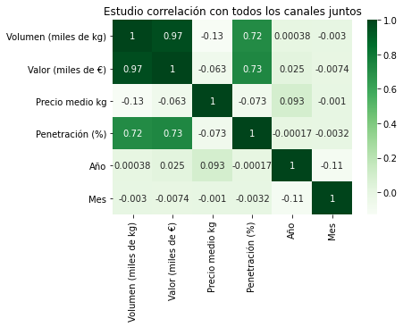

```python
# Estudiamos la posible correlación entre las diferentes variables
sns.heatmap(df_total.corr(),annot=True, cmap= 'Greens').set_title("Estudio correlación con todos los canales juntos")
```